# Risk Factor Analysis

## Outcome Variable

**Outcome Variable:** ever_stunted

## Predictor Variables

**Intervention Variable:** hdlvry

**Adjustment Set:**

unadjusted

## Stratifying Variables

The analysis was stratified on these variable(s):

- agecat
- studyid
- country

## Data Summary

| agecat | studyid | country | hdlvry | ever_stunted | n_cell | n |
| --- | --- | --- | --- | --- | --- | --- |
| 0-24 months (no birth st.) | ki1000108-CMC-V-BCS-2002 | INDIA | 0 | 0 | 27 | 293 |
| 0-24 months (no birth st.) | ki1000108-CMC-V-BCS-2002 | INDIA | 0 | 1 | 260 | 293 |
| 0-24 months (no birth st.) | ki1000108-CMC-V-BCS-2002 | INDIA | 1 | 0 | 1 | 293 |
| 0-24 months (no birth st.) | ki1000108-CMC-V-BCS-2002 | INDIA | 1 | 1 | 5 | 293 |
| 0-24 months (no birth st.) | ki1000108-IRC | INDIA | 0 | 0 | 145 | 360 |
| 0-24 months (no birth st.) | ki1000108-IRC | INDIA | 0 | 1 | 208 | 360 |
| 0-24 months (no birth st.) | ki1000108-IRC | INDIA | 1 | 0 | 2 | 360 |
| 0-24 months (no birth st.) | ki1000108-IRC | INDIA | 1 | 1 | 5 | 360 |
| 0-24 months (no birth st.) | ki1000109-EE | PAKISTAN | 0 | 0 | 50 | 494 |
| 0-24 months (no birth st.) | ki1000109-EE | PAKISTAN | 0 | 1 | 274 | 494 |
| 0-24 months (no birth st.) | ki1000109-EE | PAKISTAN | 1 | 0 | 16 | 494 |
| 0-24 months (no birth st.) | ki1000109-EE | PAKISTAN | 1 | 1 | 154 | 494 |
| 0-24 months (no birth st.) | ki1000304b-SAS-CompFeed | INDIA | 0 | 0 | 57 | 887 |
| 0-24 months (no birth st.) | ki1000304b-SAS-CompFeed | INDIA | 0 | 1 | 56 | 887 |
| 0-24 months (no birth st.) | ki1000304b-SAS-CompFeed | INDIA | 1 | 0 | 296 | 887 |
| 0-24 months (no birth st.) | ki1000304b-SAS-CompFeed | INDIA | 1 | 1 | 478 | 887 |
| 0-24 months (no birth st.) | ki1000304b-SAS-FoodSuppl | INDIA | 0 | 0 | 18 | 257 |
| 0-24 months (no birth st.) | ki1000304b-SAS-FoodSuppl | INDIA | 0 | 1 | 40 | 257 |
| 0-24 months (no birth st.) | ki1000304b-SAS-FoodSuppl | INDIA | 1 | 0 | 54 | 257 |
| 0-24 months (no birth st.) | ki1000304b-SAS-FoodSuppl | INDIA | 1 | 1 | 145 | 257 |
| 0-24 months (no birth st.) | ki1017093b-PROVIDE | BANGLADESH | 0 | 0 | 299 | 634 |
| 0-24 months (no birth st.) | ki1017093b-PROVIDE | BANGLADESH | 0 | 1 | 170 | 634 |
| 0-24 months (no birth st.) | ki1017093b-PROVIDE | BANGLADESH | 1 | 0 | 97 | 634 |
| 0-24 months (no birth st.) | ki1017093b-PROVIDE | BANGLADESH | 1 | 1 | 68 | 634 |
| 0-24 months (no birth st.) | ki1017093c-NIH-Crypto | BANGLADESH | 0 | 0 | 320 | 653 |
| 0-24 months (no birth st.) | ki1017093c-NIH-Crypto | BANGLADESH | 0 | 1 | 194 | 653 |
| 0-24 months (no birth st.) | ki1017093c-NIH-Crypto | BANGLADESH | 1 | 0 | 76 | 653 |
| 0-24 months (no birth st.) | ki1017093c-NIH-Crypto | BANGLADESH | 1 | 1 | 63 | 653 |
| 0-24 months (no birth st.) | ki1066203-TanzaniaChild2 | TANZANIA, UNITED REPUBLIC OF | 0 | 0 | 1465 | 2129 |
| 0-24 months (no birth st.) | ki1066203-TanzaniaChild2 | TANZANIA, UNITED REPUBLIC OF | 0 | 1 | 626 | 2129 |

[output cut: 114 more lines]

The following strata were considered:

- agecat: 0-24 months (no birth st.), studyid: ki1000108-CMC-V-BCS-2002, country: INDIA
- agecat: 0-24 months (no birth st.), studyid: ki1000108-IRC, country: INDIA
- agecat: 0-24 months (no birth st.), studyid: ki1000109-EE, country: PAKISTAN
- agecat: 0-24 months (no birth st.), studyid: ki1000304b-SAS-CompFeed, country: INDIA
- agecat: 0-24 months (no birth st.), studyid: ki1000304b-SAS-FoodSuppl, country: INDIA
- agecat: 0-24 months (no birth st.), studyid: ki1017093b-PROVIDE, country: BANGLADESH
- agecat: 0-24 months (no birth st.), studyid: ki1017093c-NIH-Crypto, country: BANGLADESH
- agecat: 0-24 months (no birth st.), studyid: ki1066203-TanzaniaChild2, country: TANZANIA, UNITED REPUBLIC OF
- agecat: 0-24 months (no birth st.), studyid: ki1113344-GMS-Nepal, country: NEPAL
- agecat: 0-24 months (no birth st.), studyid: ki1135781-COHORTS, country: INDIA
- agecat: 0-24 months (no birth st.), studyid: kiGH5241-JiVitA-3, country: BANGLADESH
- agecat: 0-24 months (no birth st.), studyid: kiGH5241-JiVitA-4, country: BANGLADESH
- agecat: 0-6 months (no birth st.), studyid: ki1000108-CMC-V-BCS-2002, country: INDIA
- agecat: 0-6 months (no birth st.), studyid: ki1000108-IRC, country: INDIA
- agecat: 0-6 months (no birth st.), studyid: ki1000109-EE, country: PAKISTAN
- agecat: 0-6 months (no birth st.), studyid: ki1000304b-SAS-CompFeed, country: INDIA
- agecat: 0-6 months (no birth st.), studyid: ki1000304b-SAS-FoodSuppl, country: INDIA
- agecat: 0-6 months (no birth st.), studyid: ki1017093b-PROVIDE, country: BANGLADESH
- agecat: 0-6 months (no birth st.), studyid: ki1017093c-NIH-Crypto, country: BANGLADESH
- agecat: 0-6 months (no birth st.), studyid: ki1066203-TanzaniaChild2, country: TANZANIA, UNITED REPUBLIC OF
- agecat: 0-6 months (no birth st.), studyid: ki1113344-GMS-Nepal, country: NEPAL
- agecat: 0-6 months (no birth st.), studyid: ki1135781-COHORTS, country: INDIA
- agecat: 0-6 months (no birth st.), studyid: kiGH5241-JiVitA-3, country: BANGLADESH
- agecat: 0-6 months (no birth st.), studyid: kiGH5241-JiVitA-4, country: BANGLADESH
- agecat: 6-24 months, studyid: ki1000108-CMC-V-BCS-2002, country: INDIA
- agecat: 6-24 months, studyid: ki1000108-IRC, country: INDIA
- agecat: 6-24 months, studyid: ki1000109-EE, country: PAKISTAN
- agecat: 6-24 months, studyid: ki1000304b-SAS-CompFeed, country: INDIA
- agecat: 6-24 months, studyid: ki1000304b-SAS-FoodSuppl, country: INDIA
- agecat: 6-24 months, studyid: ki1017093b-PROVIDE, country: BANGLADESH
- agecat: 6-24 months, studyid: ki1017093c-NIH-Crypto, country: BANGLADESH
- agecat: 6-24 months, studyid: ki1066203-TanzaniaChild2, country: TANZANIA, UNITED REPUBLIC OF
- agecat: 6-24 months, studyid: ki1113344-GMS-Nepal, country: NEPAL
- agecat: 6-24 months, studyid: ki1135781-COHORTS, country: INDIA
- agecat: 6-24 months, studyid: kiGH5241-JiVitA-3, country: BANGLADESH
- agecat: 6-24 months, studyid: kiGH5241-JiVitA-4, country: BANGLADESH

### Dropped Strata

Some strata were dropped due to rare outcomes:

- agecat: 0-24 months (no birth st.), studyid: ki1000108-CMC-V-BCS-2002, country: INDIA
- agecat: 0-24 months (no birth st.), studyid: ki1000108-IRC, country: INDIA
- agecat: 0-6 months (no birth st.), studyid: ki1000108-CMC-V-BCS-2002, country: INDIA
- agecat: 0-6 months (no birth st.), studyid: ki1000108-IRC, country: INDIA
- agecat: 0-6 months (no birth st.), studyid: ki1000304b-SAS-FoodSuppl, country: INDIA
- agecat: 0-6 months (no birth st.), studyid: kiGH5241-JiVitA-3, country: BANGLADESH
- agecat: 6-24 months, studyid: ki1000108-CMC-V-BCS-2002, country: INDIA
- agecat: 6-24 months, studyid: ki1000108-IRC, country: INDIA

## Methods Detail

We’re interested in the causal parameters $E[Y_a]$ for all values of $a \in \mathcal{A}$. These parameters represent the mean outcome if, possibly contrary to fact, we intervened to set all units to have $A=a$. Under the randomization and positivity assumptions, these are identified by the statistical parameters $\psi_a=E_W[E_{Y|A,W}(Y|A=a,W)]$. In addition, we’re interested in the mean of $Y$, $E[Y]$ under no intervention (the observed mean). We will estimate these parameters by using SuperLearner to fit the relevant likelihood factors – $E_{Y|A,W}(Y|A=a,W)$ and $p(A=a|W)$, and then updating our likelihood fit using a joint TMLE.

For unadjusted analyses ($W=\{\}$), initial likelihoods were estimated using Lrnr_glm to estimate the simple $E(Y|A)$ and Lrnr_mean to estimate $p(A)$. For adjusted analyses, a small library containing Lrnr_glmnet, Lrnr_xgboost, and Lrnr_mean was used.

Having estimated these parameters, we will then use the delta method to estimate relative risks and attributable risks relative to a prespecified baseline level of $A$.

# Results Detail

## Results Plots

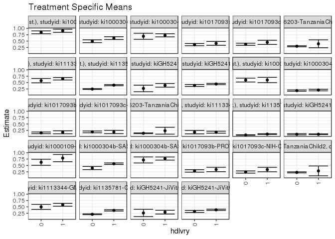

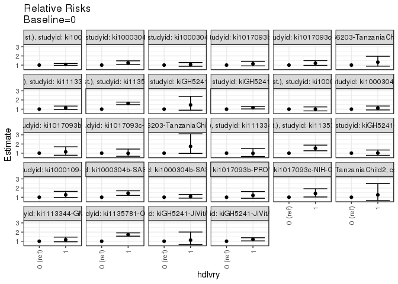

[figure not shown]

[figure not shown]

## Results Table

### Parameter: TSM

| agecat | studyid | country | intervention_level | baseline_level | estimate | ci_lower | ci_upper |
| --- | --- | --- | --- | --- | --- | --- | --- |
| 0-24 months (no birth st.) | ki1000109-EE | PAKISTAN | 0 | NA | 0.8456790 | 0.7899365 | 0.9014216 |
| 0-24 months (no birth st.) | ki1000109-EE | PAKISTAN | 1 | NA | 0.9058823 | 0.8436823 | 0.9680824 |
| 0-24 months (no birth st.) | ki1000304b-SAS-CompFeed | INDIA | 0 | NA | 0.4955752 | 0.4404578 | 0.5506926 |
| 0-24 months (no birth st.) | ki1000304b-SAS-CompFeed | INDIA | 1 | NA | 0.6175711 | 0.5620734 | 0.6730687 |
| 0-24 months (no birth st.) | ki1000304b-SAS-FoodSuppl | INDIA | 0 | NA | 0.6896552 | 0.5703611 | 0.8089493 |
| 0-24 months (no birth st.) | ki1000304b-SAS-FoodSuppl | INDIA | 1 | NA | 0.7286432 | 0.6667425 | 0.7905440 |
| 0-24 months (no birth st.) | ki1017093b-PROVIDE | BANGLADESH | 0 | NA | 0.3624733 | 0.3189330 | 0.4060137 |
| 0-24 months (no birth st.) | ki1017093b-PROVIDE | BANGLADESH | 1 | NA | 0.4121212 | 0.3369580 | 0.4872844 |
| 0-24 months (no birth st.) | ki1017093c-NIH-Crypto | BANGLADESH | 0 | NA | 0.3774319 | 0.3354935 | 0.4193703 |
| 0-24 months (no birth st.) | ki1017093c-NIH-Crypto | BANGLADESH | 1 | NA | 0.4532374 | 0.3704173 | 0.5360575 |
| 0-24 months (no birth st.) | ki1066203-TanzaniaChild2 | TANZANIA, UNITED REPUBLIC OF | 0 | NA | 0.2993783 | 0.2797436 | 0.3190130 |
| 0-24 months (no birth st.) | ki1066203-TanzaniaChild2 | TANZANIA, UNITED REPUBLIC OF | 1 | NA | 0.3947368 | 0.2392892 | 0.5501845 |
| 0-24 months (no birth st.) | ki1113344-GMS-Nepal | NEPAL | 0 | NA | 0.5748031 | 0.4887360 | 0.6608703 |
| 0-24 months (no birth st.) | ki1113344-GMS-Nepal | NEPAL | 1 | NA | 0.6495957 | 0.6009993 | 0.6981921 |
| 0-24 months (no birth st.) | ki1135781-COHORTS | INDIA | 0 | NA | 0.2460545 | 0.2300650 | 0.2620441 |
| 0-24 months (no birth st.) | ki1135781-COHORTS | INDIA | 1 | NA | 0.3985807 | 0.3752423 | 0.4219191 |
| 0-24 months (no birth st.) | kiGH5241-JiVitA-3 | BANGLADESH | 0 | NA | 0.2686567 | 0.1399132 | 0.3974002 |
| 0-24 months (no birth st.) | kiGH5241-JiVitA-3 | BANGLADESH | 1 | NA | 0.3911111 | 0.3202504 | 0.4619718 |
| 0-24 months (no birth st.) | kiGH5241-JiVitA-4 | BANGLADESH | 0 | NA | 0.3856655 | 0.3464678 | 0.4248633 |
| 0-24 months (no birth st.) | kiGH5241-JiVitA-4 | BANGLADESH | 1 | NA | 0.4433146 | 0.4190635 | 0.4675656 |
| 0-6 months (no birth st.) | ki1000109-EE | PAKISTAN | 0 | NA | 0.5987654 | 0.5231346 | 0.6743963 |
| 0-6 months (no birth st.) | ki1000109-EE | PAKISTAN | 1 | NA | 0.6000000 | 0.4956421 | 0.7043579 |
| 0-6 months (no birth st.) | ki1000304b-SAS-CompFeed | INDIA | 0 | NA | 0.1858407 | 0.1600108 | 0.2116706 |
| 0-6 months (no birth st.) | ki1000304b-SAS-CompFeed | INDIA | 1 | NA | 0.2054264 | 0.1750420 | 0.2358107 |
| 0-6 months (no birth st.) | ki1017093b-PROVIDE | BANGLADESH | 0 | NA | 0.1535181 | 0.1208674 | 0.1861689 |
| 0-6 months (no birth st.) | ki1017093b-PROVIDE | BANGLADESH | 1 | NA | 0.1757576 | 0.1176365 | 0.2338786 |
| 0-6 months (no birth st.) | ki1017093c-NIH-Crypto | BANGLADESH | 0 | NA | 0.1906615 | 0.1566758 | 0.2246472 |
| 0-6 months (no birth st.) | ki1017093c-NIH-Crypto | BANGLADESH | 1 | NA | 0.1870504 | 0.1221743 | 0.2519264 |
| 0-6 months (no birth st.) | ki1066203-TanzaniaChild2 | TANZANIA, UNITED REPUBLIC OF | 0 | NA | 0.1358202 | 0.1211324 | 0.1505080 |
| 0-6 months (no birth st.) | ki1066203-TanzaniaChild2 | TANZANIA, UNITED REPUBLIC OF | 1 | NA | 0.2368421 | 0.1016364 | 0.3720478 |
| 0-6 months (no birth st.) | ki1113344-GMS-Nepal | NEPAL | 0 | NA | 0.1811024 | 0.1140584 | 0.2481463 |
| 0-6 months (no birth st.) | ki1113344-GMS-Nepal | NEPAL | 1 | NA | 0.1778976 | 0.1389442 | 0.2168510 |
| 0-6 months (no birth st.) | ki1135781-COHORTS | INDIA | 0 | NA | 0.0674530 | 0.0580144 | 0.0768916 |
| 0-6 months (no birth st.) | ki1135781-COHORTS | INDIA | 1 | NA | 0.1039275 | 0.0892235 | 0.1186315 |
| 0-6 months (no birth st.) | kiGH5241-JiVitA-4 | BANGLADESH | 0 | NA | 0.0968109 | 0.0728909 | 0.1207309 |
| 0-6 months (no birth st.) | kiGH5241-JiVitA-4 | BANGLADESH | 1 | NA | 0.0983536 | 0.0839023 | 0.1128048 |
| 6-24 months | ki1000109-EE | PAKISTAN | 0 | NA | 0.6250000 | 0.5057759 | 0.7442241 |
| 6-24 months | ki1000109-EE | PAKISTAN | 1 | NA | 0.7878788 | 0.6476739 | 0.9280837 |
| 6-24 months | ki1000304b-SAS-CompFeed | INDIA | 0 | NA | 0.3977273 | 0.3352129 | 0.4602416 |
| 6-24 months | ki1000304b-SAS-CompFeed | INDIA | 1 | NA | 0.5681416 | 0.5394797 | 0.5968034 |
| 6-24 months | ki1000304b-SAS-FoodSuppl | INDIA | 0 | NA | 0.7142857 | 0.5957221 | 0.8328493 |
| 6-24 months | ki1000304b-SAS-FoodSuppl | INDIA | 1 | NA | 0.7700535 | 0.7096174 | 0.8304896 |
| 6-24 months | ki1017093b-PROVIDE | BANGLADESH | 0 | NA | 0.2857143 | 0.2378536 | 0.3335749 |
| 6-24 months | ki1017093b-PROVIDE | BANGLADESH | 1 | NA | 0.3421053 | 0.2549227 | 0.4292878 |
| 6-24 months | ki1017093c-NIH-Crypto | BANGLADESH | 0 | NA | 0.2418136 | 0.1996526 | 0.2839746 |
| 6-24 months | ki1017093c-NIH-Crypto | BANGLADESH | 1 | NA | 0.3394495 | 0.2504670 | 0.4284321 |
| 6-24 months | ki1066203-TanzaniaChild2 | TANZANIA, UNITED REPUBLIC OF | 0 | NA | 0.2273936 | 0.2062034 | 0.2485838 |
| 6-24 months | ki1066203-TanzaniaChild2 | TANZANIA, UNITED REPUBLIC OF | 1 | NA | 0.2857143 | 0.0924361 | 0.4789925 |
| 6-24 months | ki1113344-GMS-Nepal | NEPAL | 0 | NA | 0.5000000 | 0.4018791 | 0.5981209 |
| 6-24 months | ki1113344-GMS-Nepal | NEPAL | 1 | NA | 0.5833333 | 0.5274755 | 0.6391911 |
| 6-24 months | ki1135781-COHORTS | INDIA | 0 | NA | 0.2101183 | 0.1939879 | 0.2262487 |
| 6-24 months | ki1135781-COHORTS | INDIA | 1 | NA | 0.3626142 | 0.3376323 | 0.3875961 |
| 6-24 months | kiGH5241-JiVitA-3 | BANGLADESH | 0 | NA | 0.2622951 | 0.1197087 | 0.4048815 |
| 6-24 months | kiGH5241-JiVitA-3 | BANGLADESH | 1 | NA | 0.2941176 | 0.2210826 | 0.3671527 |
| 6-24 months | kiGH5241-JiVitA-4 | BANGLADESH | 0 | NA | 0.3211356 | 0.2808296 | 0.3614417 |
| 6-24 months | kiGH5241-JiVitA-4 | BANGLADESH | 1 | NA | 0.3849292 | 0.3599792 | 0.4098792 |

### Parameter: E(Y)

| agecat | studyid | country | intervention_level | baseline_level | estimate | ci_lower | ci_upper |
| --- | --- | --- | --- | --- | --- | --- | --- |
| 0-24 months (no birth st.) | ki1000109-EE | PAKISTAN | NA | NA | 0.8663968 | 0.8238812 | 0.9089123 |
| 0-24 months (no birth st.) | ki1000304b-SAS-CompFeed | INDIA | NA | NA | 0.6020293 | 0.5512634 | 0.6527952 |
| 0-24 months (no birth st.) | ki1000304b-SAS-FoodSuppl | INDIA | NA | NA | 0.7198444 | 0.6648337 | 0.7748550 |
| 0-24 months (no birth st.) | ki1017093b-PROVIDE | BANGLADESH | NA | NA | 0.3753943 | 0.3376725 | 0.4131162 |
| 0-24 months (no birth st.) | ki1017093c-NIH-Crypto | BANGLADESH | NA | NA | 0.3935681 | 0.3560687 | 0.4310676 |
| 0-24 months (no birth st.) | ki1066203-TanzaniaChild2 | TANZANIA, UNITED REPUBLIC OF | NA | NA | 0.3010803 | 0.2815901 | 0.3205706 |
| 0-24 months (no birth st.) | ki1113344-GMS-Nepal | NEPAL | NA | NA | 0.6305221 | 0.5880881 | 0.6729561 |
| 0-24 months (no birth st.) | ki1135781-COHORTS | INDIA | NA | NA | 0.3036392 | 0.2901712 | 0.3171072 |
| 0-24 months (no birth st.) | kiGH5241-JiVitA-3 | BANGLADESH | NA | NA | 0.3752418 | 0.3097755 | 0.4407081 |
| 0-24 months (no birth st.) | kiGH5241-JiVitA-4 | BANGLADESH | NA | NA | 0.4274295 | 0.4069942 | 0.4478647 |
| 0-6 months (no birth st.) | ki1000109-EE | PAKISTAN | NA | NA | 0.5991903 | 0.5379507 | 0.6604298 |
| 0-6 months (no birth st.) | ki1000304b-SAS-CompFeed | INDIA | NA | NA | 0.2029312 | 0.1748514 | 0.2310111 |
| 0-6 months (no birth st.) | ki1017093b-PROVIDE | BANGLADESH | NA | NA | 0.1593060 | 0.1307970 | 0.1878149 |
| 0-6 months (no birth st.) | ki1017093c-NIH-Crypto | BANGLADESH | NA | NA | 0.1898928 | 0.1597870 | 0.2199986 |
| 0-6 months (no birth st.) | ki1066203-TanzaniaChild2 | TANZANIA, UNITED REPUBLIC OF | NA | NA | 0.1376233 | 0.1229861 | 0.1522605 |
| 0-6 months (no birth st.) | ki1113344-GMS-Nepal | NEPAL | NA | NA | 0.1787149 | 0.1450329 | 0.2123968 |
| 0-6 months (no birth st.) | ki1135781-COHORTS | INDIA | NA | NA | 0.0812729 | 0.0731685 | 0.0893773 |
| 0-6 months (no birth st.) | kiGH5241-JiVitA-4 | BANGLADESH | NA | NA | 0.0979284 | 0.0852731 | 0.1105838 |
| 6-24 months | ki1000109-EE | PAKISTAN | NA | NA | 0.6804124 | 0.5871313 | 0.7736934 |
| 6-24 months | ki1000304b-SAS-CompFeed | INDIA | NA | NA | 0.5451761 | 0.5131549 | 0.5771973 |
| 6-24 months | ki1000304b-SAS-FoodSuppl | INDIA | NA | NA | 0.7572016 | 0.7031798 | 0.8112234 |
| 6-24 months | ki1017093b-PROVIDE | BANGLADESH | NA | NA | 0.2997812 | 0.2577294 | 0.3418330 |
| 6-24 months | ki1017093c-NIH-Crypto | BANGLADESH | NA | NA | 0.2628458 | 0.2244546 | 0.3012371 |
| 6-24 months | ki1066203-TanzaniaChild2 | TANZANIA, UNITED REPUBLIC OF | NA | NA | 0.2281967 | 0.2071268 | 0.2492667 |
| 6-24 months | ki1113344-GMS-Nepal | NEPAL | NA | NA | 0.5625000 | 0.5138243 | 0.6111757 |
| 6-24 months | ki1135781-COHORTS | INDIA | NA | NA | 0.2661332 | 0.2522150 | 0.2800514 |
| 6-24 months | kiGH5241-JiVitA-3 | BANGLADESH | NA | NA | 0.2896552 | 0.2225771 | 0.3567332 |
| 6-24 months | kiGH5241-JiVitA-4 | BANGLADESH | NA | NA | 0.3673505 | 0.3463877 | 0.3883133 |

### Parameter: RR

| agecat | studyid | country | intervention_level | baseline_level | estimate | ci_lower | ci_upper |
| --- | --- | --- | --- | --- | --- | --- | --- |
| 0-24 months (no birth st.) | ki1000109-EE | PAKISTAN | 0 | 0 | 1.000000 | 1.0000000 | 1.000000 |
| 0-24 months (no birth st.) | ki1000109-EE | PAKISTAN | 1 | 0 | 1.071189 | 0.9739352 | 1.178155 |
| 0-24 months (no birth st.) | ki1000304b-SAS-CompFeed | INDIA | 0 | 0 | 1.000000 | 1.0000000 | 1.000000 |
| 0-24 months (no birth st.) | ki1000304b-SAS-CompFeed | INDIA | 1 | 0 | 1.246170 | 1.0607143 | 1.464051 |
| 0-24 months (no birth st.) | ki1000304b-SAS-FoodSuppl | INDIA | 0 | 0 | 1.000000 | 1.0000000 | 1.000000 |
| 0-24 months (no birth st.) | ki1000304b-SAS-FoodSuppl | INDIA | 1 | 0 | 1.056533 | 0.8713430 | 1.281081 |
| 0-24 months (no birth st.) | ki1017093b-PROVIDE | BANGLADESH | 0 | 0 | 1.000000 | 1.0000000 | 1.000000 |
| 0-24 months (no birth st.) | ki1017093b-PROVIDE | BANGLADESH | 1 | 0 | 1.136970 | 0.9139148 | 1.414465 |
| 0-24 months (no birth st.) | ki1017093c-NIH-Crypto | BANGLADESH | 0 | 0 | 1.000000 | 1.0000000 | 1.000000 |
| 0-24 months (no birth st.) | ki1017093c-NIH-Crypto | BANGLADESH | 1 | 0 | 1.200846 | 0.9696347 | 1.487189 |
| 0-24 months (no birth st.) | ki1066203-TanzaniaChild2 | TANZANIA, UNITED REPUBLIC OF | 0 | 0 | 1.000000 | 1.0000000 | 1.000000 |
| 0-24 months (no birth st.) | ki1066203-TanzaniaChild2 | TANZANIA, UNITED REPUBLIC OF | 1 | 0 | 1.318522 | 0.8845171 | 1.965479 |
| 0-24 months (no birth st.) | ki1113344-GMS-Nepal | NEPAL | 0 | 0 | 1.000000 | 1.0000000 | 1.000000 |
| 0-24 months (no birth st.) | ki1113344-GMS-Nepal | NEPAL | 1 | 0 | 1.130119 | 0.9559410 | 1.336032 |
| 0-24 months (no birth st.) | ki1135781-COHORTS | INDIA | 0 | 0 | 1.000000 | 1.0000000 | 1.000000 |
| 0-24 months (no birth st.) | ki1135781-COHORTS | INDIA | 1 | 0 | 1.619888 | 1.4842127 | 1.767965 |
| 0-24 months (no birth st.) | kiGH5241-JiVitA-3 | BANGLADESH | 0 | 0 | 1.000000 | 1.0000000 | 1.000000 |
| 0-24 months (no birth st.) | kiGH5241-JiVitA-3 | BANGLADESH | 1 | 0 | 1.455803 | 0.8851100 | 2.394460 |
| 0-24 months (no birth st.) | kiGH5241-JiVitA-4 | BANGLADESH | 0 | 0 | 1.000000 | 1.0000000 | 1.000000 |
| 0-24 months (no birth st.) | kiGH5241-JiVitA-4 | BANGLADESH | 1 | 0 | 1.149479 | 1.0229879 | 1.291611 |
| 0-6 months (no birth st.) | ki1000109-EE | PAKISTAN | 0 | 0 | 1.000000 | 1.0000000 | 1.000000 |
| 0-6 months (no birth st.) | ki1000109-EE | PAKISTAN | 1 | 0 | 1.002062 | 0.8082399 | 1.242364 |
| 0-6 months (no birth st.) | ki1000304b-SAS-CompFeed | INDIA | 0 | 0 | 1.000000 | 1.0000000 | 1.000000 |
| 0-6 months (no birth st.) | ki1000304b-SAS-CompFeed | INDIA | 1 | 0 | 1.105389 | 0.9098615 | 1.342936 |
| 0-6 months (no birth st.) | ki1017093b-PROVIDE | BANGLADESH | 0 | 0 | 1.000000 | 1.0000000 | 1.000000 |
| 0-6 months (no birth st.) | ki1017093b-PROVIDE | BANGLADESH | 1 | 0 | 1.144865 | 0.7726792 | 1.696327 |
| 0-6 months (no birth st.) | ki1017093c-NIH-Crypto | BANGLADESH | 0 | 0 | 1.000000 | 1.0000000 | 1.000000 |
| 0-6 months (no birth st.) | ki1017093c-NIH-Crypto | BANGLADESH | 1 | 0 | 0.981060 | 0.6642592 | 1.448951 |
| 0-6 months (no birth st.) | ki1066203-TanzaniaChild2 | TANZANIA, UNITED REPUBLIC OF | 0 | 0 | 1.000000 | 1.0000000 | 1.000000 |
| 0-6 months (no birth st.) | ki1066203-TanzaniaChild2 | TANZANIA, UNITED REPUBLIC OF | 1 | 0 | 1.743792 | 0.9753498 | 3.117661 |
| 0-6 months (no birth st.) | ki1113344-GMS-Nepal | NEPAL | 0 | 0 | 1.000000 | 1.0000000 | 1.000000 |
| 0-6 months (no birth st.) | ki1113344-GMS-Nepal | NEPAL | 1 | 0 | 0.982304 | 0.6389284 | 1.510218 |
| 0-6 months (no birth st.) | ki1135781-COHORTS | INDIA | 0 | 0 | 1.000000 | 1.0000000 | 1.000000 |
| 0-6 months (no birth st.) | ki1135781-COHORTS | INDIA | 1 | 0 | 1.540739 | 1.2627234 | 1.879966 |
| 0-6 months (no birth st.) | kiGH5241-JiVitA-4 | BANGLADESH | 0 | 0 | 1.000000 | 1.0000000 | 1.000000 |
| 0-6 months (no birth st.) | kiGH5241-JiVitA-4 | BANGLADESH | 1 | 0 | 1.015934 | 0.7671605 | 1.345380 |
| 6-24 months | ki1000109-EE | PAKISTAN | 0 | 0 | 1.000000 | 1.0000000 | 1.000000 |
| 6-24 months | ki1000109-EE | PAKISTAN | 1 | 0 | 1.260606 | 0.9711420 | 1.636349 |
| 6-24 months | ki1000304b-SAS-CompFeed | INDIA | 0 | 0 | 1.000000 | 1.0000000 | 1.000000 |
| 6-24 months | ki1000304b-SAS-CompFeed | INDIA | 1 | 0 | 1.428470 | 1.1997465 | 1.700799 |
| 6-24 months | ki1000304b-SAS-FoodSuppl | INDIA | 0 | 0 | 1.000000 | 1.0000000 | 1.000000 |
| 6-24 months | ki1000304b-SAS-FoodSuppl | INDIA | 1 | 0 | 1.078075 | 0.8972406 | 1.295355 |
| 6-24 months | ki1017093b-PROVIDE | BANGLADESH | 0 | 0 | 1.000000 | 1.0000000 | 1.000000 |
| 6-24 months | ki1017093b-PROVIDE | BANGLADESH | 1 | 0 | 1.197368 | 0.8826380 | 1.624325 |
| 6-24 months | ki1017093c-NIH-Crypto | BANGLADESH | 0 | 0 | 1.000000 | 1.0000000 | 1.000000 |
| 6-24 months | ki1017093c-NIH-Crypto | BANGLADESH | 1 | 0 | 1.403765 | 1.0246307 | 1.923188 |
| 6-24 months | ki1066203-TanzaniaChild2 | TANZANIA, UNITED REPUBLIC OF | 0 | 0 | 1.000000 | 1.0000000 | 1.000000 |
| 6-24 months | ki1066203-TanzaniaChild2 | TANZANIA, UNITED REPUBLIC OF | 1 | 0 | 1.256474 | 0.6347322 | 2.487235 |
| 6-24 months | ki1113344-GMS-Nepal | NEPAL | 0 | 0 | 1.000000 | 1.0000000 | 1.000000 |
| 6-24 months | ki1113344-GMS-Nepal | NEPAL | 1 | 0 | 1.166667 | 0.9378108 | 1.451371 |
| 6-24 months | ki1135781-COHORTS | INDIA | 0 | 0 | 1.000000 | 1.0000000 | 1.000000 |
| 6-24 months | ki1135781-COHORTS | INDIA | 1 | 0 | 1.725762 | 1.5566244 | 1.913277 |
| 6-24 months | kiGH5241-JiVitA-3 | BANGLADESH | 0 | 0 | 1.000000 | 1.0000000 | 1.000000 |
| 6-24 months | kiGH5241-JiVitA-3 | BANGLADESH | 1 | 0 | 1.121323 | 0.6263088 | 2.007582 |
| 6-24 months | kiGH5241-JiVitA-4 | BANGLADESH | 0 | 0 | 1.000000 | 1.0000000 | 1.000000 |
| 6-24 months | kiGH5241-JiVitA-4 | BANGLADESH | 1 | 0 | 1.198650 | 1.0389198 | 1.382938 |

### Parameter: PAR

| agecat | studyid | country | intervention_level | baseline_level | estimate | ci_lower | ci_upper |
| --- | --- | --- | --- | --- | --- | --- | --- |
| 0-24 months (no birth st.) | ki1000109-EE | PAKISTAN | 0 | NA | 0.0207177 | -0.0082463 | 0.0496818 |
| 0-24 months (no birth st.) | ki1000304b-SAS-CompFeed | INDIA | 0 | NA | 0.1064541 | 0.0264330 | 0.1864752 |
| 0-24 months (no birth st.) | ki1000304b-SAS-FoodSuppl | INDIA | 0 | NA | 0.0301892 | -0.0738968 | 0.1342752 |
| 0-24 months (no birth st.) | ki1017093b-PROVIDE | BANGLADESH | 0 | NA | 0.0129210 | -0.0097491 | 0.0355910 |
| 0-24 months (no birth st.) | ki1017093c-NIH-Crypto | BANGLADESH | 0 | NA | 0.0161362 | -0.0037676 | 0.0360401 |
| 0-24 months (no birth st.) | ki1066203-TanzaniaChild2 | TANZANIA, UNITED REPUBLIC OF | 0 | NA | 0.0017020 | -0.0011455 | 0.0045496 |
| 0-24 months (no birth st.) | ki1113344-GMS-Nepal | NEPAL | 0 | NA | 0.0557189 | -0.0179699 | 0.1294078 |
| 0-24 months (no birth st.) | ki1135781-COHORTS | INDIA | 0 | NA | 0.0575847 | 0.0466866 | 0.0684828 |
| 0-24 months (no birth st.) | kiGH5241-JiVitA-3 | BANGLADESH | 0 | NA | 0.1065851 | -0.0166833 | 0.2298534 |
| 0-24 months (no birth st.) | kiGH5241-JiVitA-4 | BANGLADESH | 0 | NA | 0.0417639 | 0.0080233 | 0.0755046 |
| 0-6 months (no birth st.) | ki1000109-EE | PAKISTAN | 0 | NA | 0.0004249 | -0.0439273 | 0.0447770 |
| 0-6 months (no birth st.) | ki1000304b-SAS-CompFeed | INDIA | 0 | NA | 0.0170905 | -0.0166890 | 0.0508700 |
| 0-6 months (no birth st.) | ki1017093b-PROVIDE | BANGLADESH | 0 | NA | 0.0057879 | -0.0115783 | 0.0231541 |
| 0-6 months (no birth st.) | ki1017093c-NIH-Crypto | BANGLADESH | 0 | NA | -0.0007687 | -0.0163590 | 0.0148216 |
| 0-6 months (no birth st.) | ki1066203-TanzaniaChild2 | TANZANIA, UNITED REPUBLIC OF | 0 | NA | 0.0018031 | -0.0006900 | 0.0042962 |
| 0-6 months (no birth st.) | ki1113344-GMS-Nepal | NEPAL | 0 | NA | -0.0023875 | -0.0601525 | 0.0553774 |
| 0-6 months (no birth st.) | ki1135781-COHORTS | INDIA | 0 | NA | 0.0138199 | 0.0071789 | 0.0204609 |
| 0-6 months (no birth st.) | kiGH5241-JiVitA-4 | BANGLADESH | 0 | NA | 0.0011175 | -0.0186597 | 0.0208947 |
| 6-24 months | ki1000109-EE | PAKISTAN | 0 | NA | 0.0554124 | -0.0090750 | 0.1198997 |
| 6-24 months | ki1000304b-SAS-CompFeed | INDIA | 0 | NA | 0.1474488 | 0.0770841 | 0.2178136 |
| 6-24 months | ki1000304b-SAS-FoodSuppl | INDIA | 0 | NA | 0.0429159 | -0.0595369 | 0.1453688 |
| 6-24 months | ki1017093b-PROVIDE | BANGLADESH | 0 | NA | 0.0140669 | -0.0108435 | 0.0389773 |
| 6-24 months | ki1017093c-NIH-Crypto | BANGLADESH | 0 | NA | 0.0210322 | -0.0004657 | 0.0425302 |
| 6-24 months | ki1066203-TanzaniaChild2 | TANZANIA, UNITED REPUBLIC OF | 0 | NA | 0.0008031 | -0.0018960 | 0.0035022 |
| 6-24 months | ki1113344-GMS-Nepal | NEPAL | 0 | NA | 0.0625000 | -0.0222536 | 0.1472536 |
| 6-24 months | ki1135781-COHORTS | INDIA | 0 | NA | 0.0560149 | 0.0448492 | 0.0671805 |
| 6-24 months | kiGH5241-JiVitA-3 | BANGLADESH | 0 | NA | 0.0273601 | -0.1066351 | 0.1613552 |
| 6-24 months | kiGH5241-JiVitA-4 | BANGLADESH | 0 | NA | 0.0462148 | 0.0113999 | 0.0810298 |

### Parameter: PAF

| agecat | studyid | country | intervention_level | baseline_level | estimate | ci_lower | ci_upper |
| --- | --- | --- | --- | --- | --- | --- | --- |
| 0-24 months (no birth st.) | ki1000109-EE | PAKISTAN | 0 | NA | 0.0239125 | -0.0103447 | 0.0570082 |
| 0-24 months (no birth st.) | ki1000304b-SAS-CompFeed | INDIA | 0 | NA | 0.1768254 | 0.0448157 | 0.2905909 |
| 0-24 months (no birth st.) | ki1000304b-SAS-FoodSuppl | INDIA | 0 | NA | 0.0419385 | -0.1143004 | 0.1762707 |
| 0-24 months (no birth st.) | ki1017093b-PROVIDE | BANGLADESH | 0 | NA | 0.0344197 | -0.0279156 | 0.0929749 |
| 0-24 months (no birth st.) | ki1017093c-NIH-Crypto | BANGLADESH | 0 | NA | 0.0409999 | -0.0109691 | 0.0902973 |
| 0-24 months (no birth st.) | ki1066203-TanzaniaChild2 | TANZANIA, UNITED REPUBLIC OF | 0 | NA | 0.0056531 | -0.0038489 | 0.0150651 |
| 0-24 months (no birth st.) | ki1113344-GMS-Nepal | NEPAL | 0 | NA | 0.0883695 | -0.0366848 | 0.1983386 |
| 0-24 months (no birth st.) | ki1135781-COHORTS | INDIA | 0 | NA | 0.1896484 | 0.1532535 | 0.2244790 |
| 0-24 months (no birth st.) | kiGH5241-JiVitA-3 | BANGLADESH | 0 | NA | 0.2840437 | -0.1245648 | 0.5441851 |
| 0-24 months (no birth st.) | kiGH5241-JiVitA-4 | BANGLADESH | 0 | NA | 0.0977095 | 0.0151365 | 0.1733595 |
| 0-6 months (no birth st.) | ki1000109-EE | PAKISTAN | 0 | NA | 0.0007090 | -0.0761216 | 0.0720543 |
| 0-6 months (no birth st.) | ki1000304b-SAS-CompFeed | INDIA | 0 | NA | 0.0842183 | -0.0893499 | 0.2301315 |
| 0-6 months (no birth st.) | ki1017093b-PROVIDE | BANGLADESH | 0 | NA | 0.0363318 | -0.0789468 | 0.1392936 |
| 0-6 months (no birth st.) | ki1017093c-NIH-Crypto | BANGLADESH | 0 | NA | -0.0040479 | -0.0895971 | 0.0747844 |
| 0-6 months (no birth st.) | ki1066203-TanzaniaChild2 | TANZANIA, UNITED REPUBLIC OF | 0 | NA | 0.0131018 | -0.0051433 | 0.0310158 |
| 0-6 months (no birth st.) | ki1113344-GMS-Nepal | NEPAL | 0 | NA | -0.0133593 | -0.3940712 | 0.2633827 |
| 0-6 months (no birth st.) | ki1135781-COHORTS | INDIA | 0 | NA | 0.1700430 | 0.0858427 | 0.2464879 |
| 0-6 months (no birth st.) | kiGH5241-JiVitA-4 | BANGLADESH | 0 | NA | 0.0114114 | -0.2127338 | 0.1941287 |
| 6-24 months | ki1000109-EE | PAKISTAN | 0 | NA | 0.0814394 | -0.0205034 | 0.1731986 |
| 6-24 months | ki1000304b-SAS-CompFeed | INDIA | 0 | NA | 0.2704609 | 0.1369677 | 0.3833055 |
| 6-24 months | ki1000304b-SAS-FoodSuppl | INDIA | 0 | NA | 0.0566770 | -0.0891526 | 0.1829811 |
| 6-24 months | ki1017093b-PROVIDE | BANGLADESH | 0 | NA | 0.0469239 | -0.0398490 | 0.1264558 |
| 6-24 months | ki1017093c-NIH-Crypto | BANGLADESH | 0 | NA | 0.0800174 | -0.0052030 | 0.1580129 |
| 6-24 months | ki1066203-TanzaniaChild2 | TANZANIA, UNITED REPUBLIC OF | 0 | NA | 0.0035194 | -0.0083774 | 0.0152757 |
| 6-24 months | ki1113344-GMS-Nepal | NEPAL | 0 | NA | 0.1111111 | -0.0535521 | 0.2500385 |
| 6-24 months | ki1135781-COHORTS | INDIA | 0 | NA | 0.2104768 | 0.1680423 | 0.2507470 |
| 6-24 months | kiGH5241-JiVitA-3 | BANGLADESH | 0 | NA | 0.0944575 | -0.5058360 | 0.4554471 |
| 6-24 months | kiGH5241-JiVitA-4 | BANGLADESH | 0 | NA | 0.1258058 | 0.0255494 | 0.2157474 |